# Causalness, frequency, diachrony and the causal-noncausal alternation in Italian and Spanish

VNC - Identifying significant stages in the development of the causal/noncausal alternation

Giulia Mazzola (Newcastle University) and Guglielmo Inglese (Università di Torino)

April 2025

```r
library(tidyverse)
library(lme4)
library(kableExtra)
library(DT)
library(data.table)
library(wesanderson)
library(here)

setwd(here::here())
getwd()
```

```
## [1] "C:/Users/Giulia/OneDrive - KU Leuven/2023_Anticausatives/romance_data/frequency_new_apr25"
```

```r
  romall<-readxl::read_excel("romance_all_bruciare_clean_new_vnc_final.xlsx")

  nrow(romall)
```

```
## [1] 14625
```

```r
   nc<-readxl::read_excel("romance_noncaus_feb24_filteredverbs_final.xlsx")

  nrow(nc)
```

```
## [1] 5154
```

```r
any(duplicated(romall$id))  # TRUE if duplicates exist
```

```
## [1] TRUE
```

```r
any(duplicated(nc$id))
```

```
## [1] TRUE
```

```r
  romall %>%
  count(id) %>%
  filter(n > 1)
```

```
## # A tibble: 1 × 2
##   id         n
##   <chr>  <int>
## 1 IT1655     4
```

```r
  romall %>%
  count(id) %>%
  filter(n > 1)
```

```
## # A tibble: 1 × 2
##   id         n
##   <chr>  <int>
## 1 IT1655     4
```

```r
  romall %>%
  filter(duplicated(id) | duplicated(id, fromLast = TRUE)) %>%
  arrange(id)
```

```
## # A tibble: 4 × 56
##   id     text            lemma  nonfinite_head periphrasis left_context  hit_new
##   <chr>  <chr>           <chr>  <chr>          <chr>       <chr>         <chr>
## 1 IT1655 SCI2_BRA_PLIN00 ardere <NA>           <NA>        , quale fo v… ardendo
## 2 IT1655 SCI2_BRA_PLIN00 ardere <NA>           <NA>        , quale fo v… ardendo
## 3 IT1655 SCI2_BRA_PLIN00 ardere <NA>           <NA>        , quale fo v… ardend…
## 4 IT1655 SCI2_BRA_PLIN00 ardere <NA>           <NA>        , quale fo v… ardend…
## # ℹ 49 more variables: right_context <chr>, semantics <chr>, coding <chr>,
## #   causative_coding <chr>, antc_marker <chr>, tense <chr>, tense2 <chr>,
## #   composto <chr>, Auxiliary <chr>, nonfin_class <chr>, finiteness <chr>,
## #   mood <chr>, time <chr>, aspect <chr>, voice <chr>, telicity <chr>,
## #   causeexpr <chr>, intens <chr>, reflpriming <chr>, animacy <chr>,
## #   control <chr>, subjcoding <chr>, note <chr>, lexsemantics <lgl>,
## #   author <chr>, genre.detail <chr>, genre <chr>, meaning <chr>, …
```

```r
  nc %>%
  filter(duplicated(id) | duplicated(id, fromLast = TRUE)) %>%
  arrange(id)
```

```
## # A tibble: 4 × 57
##   id     text            lemma  nonfinite_head periphrasis left_context  hit_new
##   <chr>  <chr>           <chr>  <chr>          <chr>       <chr>         <chr>
## 1 IT1655 SCI2_BRA_PLIN00 ardere <NA>           <NA>        , quale fo v… ardendo
## 2 IT1655 SCI2_BRA_PLIN00 ardere <NA>           <NA>        , quale fo v… ardendo
## 3 IT1655 SCI2_BRA_PLIN00 ardere <NA>           <NA>        , quale fo v… ardend…
## 4 IT1655 SCI2_BRA_PLIN00 ardere <NA>           <NA>        , quale fo v… ardend…
## # ℹ 50 more variables: right_context <chr>, semantics <chr>, coding <chr>,
## #   causative_coding <lgl>, antc_marker <chr>, tense <chr>, tense2 <chr>,
## #   composto <chr>, Auxiliary <chr>, nonfin_class <chr>, finiteness <chr>,
## #   mood <chr>, time <chr>, aspect <chr>, voice <chr>, telicity <chr>,
## #   causeexpr <chr>, intens <chr>, reflpriming <chr>, animacy <chr>,
## #   control <chr>, subjcoding <chr>, note <chr>, lexsemantics <lgl>,
## #   author <chr>, genre.detail <chr>, genre <chr>, meaning <chr>, …
```

```r
  make_ids_unique <- function(df) {
  df %>%
    group_by(id) %>%
    mutate(id = if (n() > 1) paste0(id, "_", row_number()) else id) %>%
    ungroup()
}

# Apply to both datasets
romall <- make_ids_unique(romall)
nc <- make_ids_unique(nc)
```

# Calculating the causalness degree over time

## Overall purpose

We would like to include a new predictor in our dataset, namely the **proportions of causal transitive uses (vs. non causal uses) of the verbs by time**, which we define as `causalness degree`. In order to do so we need to come up with a periodisation for our data (spanning between 1140 and 2001), which allows to calculate the relative frequency of causal uses by time. To reach a periodisation, a visual survey of the data can be instructive, it might pose the problem of the analyst’s bias, as “different researchers may arrive at different groupings even for the same data set” (Gries & Hilpert 2008:2).

## Variability neighbour clustering (VNC)

Gries & Hilpert (2008) propose a more accurate method to come up with meaningful periodisation for a given dataset: Variability-based Neighbor Clustering (VNC). It is similar to hierarchical cluster analysis (HCA), i.e. a method that displays a hierarchy of clusters, typically in the form of dendrograms with branches and leaves. Differently from HCA, VNC does justice to the chronological linearity of linguistic developments by not separating adjacent periods, and shows significant differences between periods based on the standard deviation, which is taken as similarity measure and averaging as amalgamation rule.

The analyst needs to input the proportions of a given variant (in our case, causal uses) for periods, ideally decades. The choice of the periods size is somewhat arbitrary, but making different attempts helps to find the right balance between data sparsity and significance of the VNC results. Because at various points in the diachrony of our dataset data are scarce (see Histogram), we started with periods of 20 years and ended up with periods of 70 years. The VNC periodisation based on periods of 70 years is the one with the best results in statistical terms, as the standard deviation measure for different periods are large enough to show significant differences. Hereby we show the procedure.

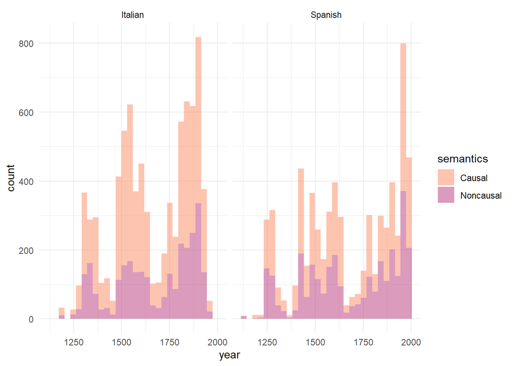

```r
ggplot(romall, aes(x=year, fill=semantics)) +
  geom_histogram(alpha = 0.5, position="stack") +
  facet_wrap(~stringr::str_to_title(language))+
  scale_fill_manual(labels=c("Causal", "Noncausal"), values= (c("#fc8961", "#b73779")))+ #wes_palette(n=2, name="GrandBudapest1"))+
  theme_minimal()
```

### Establish the 70-years periodisation

- Step 1: Split the Italian and Spanish dataset
- Step 2: Create a new variable with the years groups in 70-years periods. Periods are indicated with the central years in the 70 years span, i.e. 1175 stands for the period between 1140 and 1210.
- Step 3: Create a table with proportions of causal and noncausal uses by 70-years periods

```r
# Step 1
esp <- filter(romall, language=="spanish")
ita <- filter(romall, language=="italian")



# Step 2
esp<-esp %>%
  mutate(
    period70_es=case_when(
      year<1210 ~ "1175",
      year<1280 ~ "1245",
      year<1350 ~ "1315",
      year<1420 ~ "1385",
      year<1490 ~ "1455",
      year<1560 ~ "1525",
      year<1630 ~ "1595",
      year<1700 ~ "1665",
      year<1770 ~ "1735",
      year<1840 ~ "1805",
      year<1910 ~ "1875",
      year<1980 ~ "1945",
      year<=2001 ~ "1990"
    )
  )
which(is.na(esp$period70))
```

```
## integer(0)
```

```r
ita<-ita %>%
  mutate(
    period70_ita=case_when(
      year<1270 ~ "1235",
      year<1340 ~ "1305",
      year<1410 ~ "1375",
      year<1480 ~ "1445",
      year<1550 ~ "1515",
      year<1620 ~ "1585",
      year<1690 ~ "1655",
      year<1760 ~ "1725",
      year<1830 ~ "1795",
      year<1900 ~ "1865",
      year<1970 ~ "1935"
    )
  )
which(is.na(ita$period70))
```

```
## integer(0)
```

```r
# Step 3

es_perctable70<-table(esp$period70_es,esp$semantics)
es_perctable70<-prop.table(es_perctable70,1)*100
es_perctable70<-as.data.frame(es_perctable70)

ita_perctable70<-table(ita$period70_ita,ita$semantics)
ita_perctable70<-prop.table(ita_perctable70,1)*100
ita_perctable70<-as.data.frame(ita_perctable70)
```

The range of years in the italian dataset is 1200, 1968 and for Spanish 1140, 2001.

### Apply the Variability neighbour clustering (VNC)

- Step 1: read the VNC instructions and download the VNC file at this link
- Step 2: Rename the columns following the instructions from the website
- Step 3: visualise input table for VNC and print it as a txt file

```r
# Step 2

es_perctable70<-filter(es_perctable70, Var2== "caus") %>%
  rename(year = Var1,input = Freq) %>%
  select(year, input)

ita_perctable70<-filter(ita_perctable70, Var2== "caus") %>%
  rename(year = Var1,input = Freq) %>%
  select(year, input)

  #round up the proportions
table_ita<-ita_perctable70
table_ita$input<-round(table_ita$input, digits = 1)

table_es<-es_perctable70
table_es$input<-round(table_es$input, digits = 1)

#Step 3

table_ita %>%
  kbl(booktabs = TRUE, col.names = c("% Causal uses - Italian", paste0("70 years periods", footnote_marker_symbol(1))), escape = F, caption = "Input table for the VNC") %>%
  kable_styling()  %>%
  footnote(symbol = "Periods are indicated with the central years in the 70 years span, i.e. 1175 stands for the period between 1140 and 1210")
```

Input table for the VNC

| % Causal uses - Italian | 70 years periods* |
| --- | --- |
| 1235 | 61.7 |
| 1305 | 63.7 |
| 1375 | 63.5 |
| 1445 | 70.6 |
| 1515 | 73.6 |
| 1585 | 67.5 |
| 1655 | 61.4 |
| 1725 | 66.7 |
| 1795 | 63.0 |
| 1865 | 61.8 |
| 1935 | 60.4 |

* Periods are indicated with the central years in the 70 years span, i.e. 1175 stands for the period between 1140 and 1210

```r
table_es %>%
  kbl(booktabs = TRUE, col.names = c("% Causal uses - Spanish", paste0("70 years periods", footnote_marker_symbol(1))), escape = F, caption = "Input table for the VNC") %>%
  kable_styling()  %>%
  footnote(symbol = "Periods are indicated with the central years in the 70 years span, i.e. 1175 stands for the period between 1140 and 1210")
```

Input table for the VNC

| % Causal uses - Spanish | 70 years periods* |
| --- | --- |
| 1175 | 57.1 |
| 1245 | 53.7 |
| 1315 | 58.5 |
| 1385 | 73.0 |
| 1455 | 56.5 |
| 1525 | 56.6 |
| 1595 | 55.2 |
| 1665 | 62.8 |
| 1735 | 49.6 |
| 1805 | 51.7 |
| 1875 | 50.5 |
| 1945 | 52.0 |
| 1990 | 57.6 |

* Periods are indicated with the central years in the 70 years span, i.e. 1175 stands for the period between 1140 and 1210

```r
setcolorder (table_es, c("input", "year"))
write.table(table_es, file = "esp_vnc_caus_70y_p.txt", sep = "\t", quote = FALSE, row.names = F)

setcolorder (table_ita, c("input", "year"))
write.table(table_ita, file = "ita_vnc_caus_70y_p.txt", sep = "\t", quote = FALSE, row.names = F)
```

- Step 4: enter vnc.individual(file.choose()) and, when prompted to choose/enter a file name, choose/enter the path to the file with the data to be analyzed on the harddrive (e.g. newdata.txt).

```r
#do not run

load("vnc.individual.RData")

vtxtnc.individual("esp_vnc_caus_70y_p.txt")

load("VNC/vnc.individual.RData")

vnc.individual("VNC/ita_vnc_caus_70y.txt")
```

Running the previous script will generate two graphs in separate windows: a dendrogram and a screeplot of the type shown below:

The dendogram specifies how periods are clustered (the periods that are the most similar are amalgamated first). The analyst should asses how many development stages are considered relevant to the diachronic study. The screeplot produced by the VNC function allows the linguist to decide by comparing the distances between successive mergers (measured with standard deviations). Essentially, one should observe the slope from left to right, and take the number of clusters with the largest differences, until the slope is leveled off (i.e., until the difference between clusters is marginal). In this case 4 or 6 clusters seems adequate. Given that we want to minimise data sparsity, we make the most parsimonious choice and select the first 4 clusters.

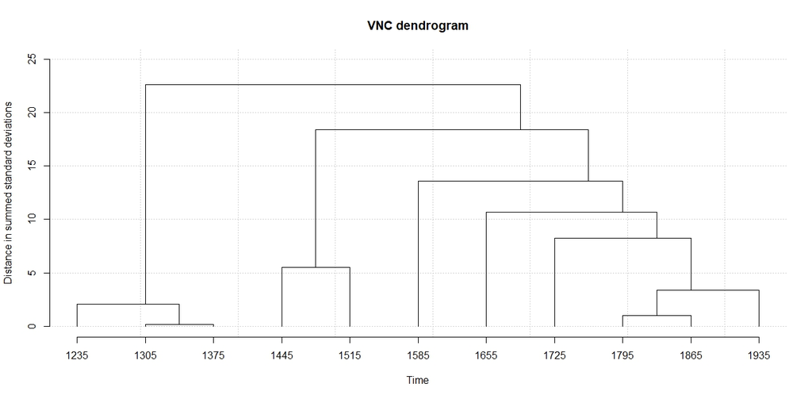

Dendogram Italian

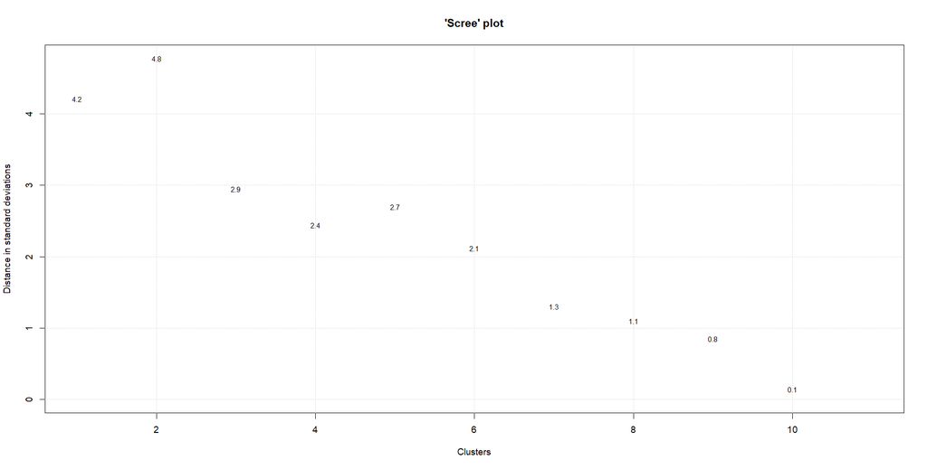

Screeplot Italian

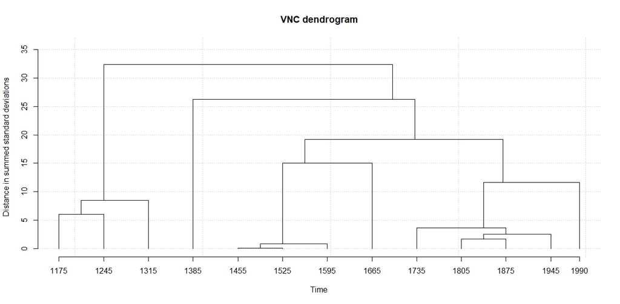

Dendogram Spanish

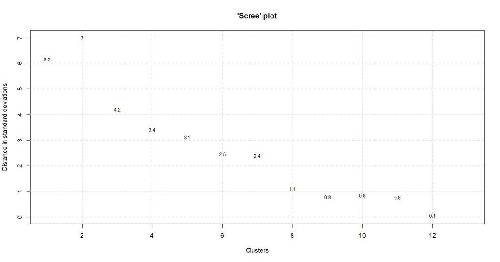

Screeplot Spanish

We identify a minimal number of relevant clusters, to avoid data sparsity. It seems reasonable to choose a 4 cluster classification for both languages.

```r
esp<-esp %>%
  mutate(
    es_vnc70_apr25=case_when(
      year<1350 ~ "1140-1349",
      year<1420 ~ "1350-1419",
      year<1700 ~ "1420-1699",
      year<2002 ~ "1700-2001"
    )
  )

summary_es<-esp %>%
  group_by (es_vnc70_apr25, semantics) %>%
  summarise (n=n()) %>%
  mutate(rel.freq = paste0(round(100 * n/sum(n), 0), "%"))

summary_es %>%  kbl(booktabs = TRUE, col.names = c("VNC periods", "Semantics", "Count", "Relative Frequency (%)"), caption = "Spanish - Summary of the verb semantics by VNC periods") %>%
   collapse_rows(column = 1) %>%
  kable_styling()
```

Spanish - Summary of the verb semantics by VNC periods

| VNC periods | Semantics | Count | Relative Frequency (%) |
| --- | --- | --- | --- |
| 1140-1349 | caus | 434 | 55% |
|  | noncaus | 348 | 45% |
| 1350-1419 | caus | 92 | 73% |
|  | noncaus | 34 | 27% |
| 1420-1699 | caus | 1367 | 57% |
|  | noncaus | 1044 | 43% |
| 1700-2001 | caus | 1653 | 52% |
|  | noncaus | 1523 | 48% |

For Italian, the relevant 4 periods indicated by the dendogram are “1200-1409”, 1410-1549, 1550-1619 and 1620-1968, Data are distributed across periods as summarised below. In Italian, causal uses are consistently more frequent than non causal ones, always higher than 60%. Their relative frequency is at the highest in the second period, when they reach 73%, like in Spanish. However, the second VNC period in Italian is about a century later than in Spanish.

```r
ita<-ita %>%
  mutate(
    ita_vnc70_apr25=case_when(
      year<1410 ~ "1200-1409",
      year<1550 ~ "1410-1549",
      year<1620 ~ "1550-1619",
      year<=1970 ~ "1620-1968"
    )
  )

summary_ita<-ita %>%
  group_by (ita_vnc70_apr25, semantics) %>%
  summarise (n=n()) %>%
  mutate(rel.freq = paste0(round(100 * n/sum(n), 0), "%"))

summary_ita %>%  kbl(booktabs = TRUE, col.names = c("VNC periods", "Semantics", "Count", "Relative Frequency (%)"), caption = "Italian - Summary of the verb semantics by VNC periods") %>%
   collapse_rows(column = 1) %>%
  kable_styling()
```

Italian - Summary of the verb semantics by VNC periods

| VNC periods | Semantics | Count | Relative Frequency (%) |
| --- | --- | --- | --- |
| 1200-1409 | caus | 768 | 64% |
|  | noncaus | 441 | 36% |
| 1410-1549 | caus | 1135 | 73% |
|  | noncaus | 421 | 27% |
| 1550-1619 | caus | 695 | 67% |
|  | noncaus | 335 | 33% |
| 1620-1968 | caus | 2700 | 62% |
|  | noncaus | 1635 | 38% |

### Calculate the `Causalness Degree`

Once we found out the significant periods for the causal/non causal alternation, we calculate the share of causal uses by verb lemma and by period. Namely, every verb lemma in each of the four periods is assigned a number between 0 and 1, indicating the proportion (%) of causal uses *vs.* non causal uses. The table below summarises the distribution of causal uses by lemma and period (variable *caus_use*).

Italian:

```r
caus_use_ita<-ita %>%
  group_by (ita_vnc70_apr25, lemma, semantics) %>%
  summarise (n=n()) %>%
  mutate(caus_use_ita_apr25 = n/sum(n))


caus_use_ita<-caus_use_ita %>% filter(semantics=="caus") %>% ungroup() %>% select (-semantics)

caus_use_ita %>% DT::datatable(rownames=F, filter="top")
```

| ita_vnc70_apr25 | lemma | n | caus_use_ita_apr25 |
| --- | --- | --- | --- |
| 1200-1409 | affondare | 1 | 0.125 |
| 1200-1409 | alzare | 23 | 0.8214285714285714 |
| 1200-1409 | aprire | 62 | 0.8857142857142857 |
| 1200-1409 | ardere | 64 | 0.5161290322580645 |
| 1200-1409 | arrestare | 1 | 0.1111111111111111 |
| 1200-1409 | bollire | 36 | 0.7659574468085106 |
| 1200-1409 | bruciare | 1 | 1 |
| 1200-1409 | chiudere | 31 | 0.6739130434782609 |
| 1200-1409 | congelare | 1 | 0.3333333333333333 |
| 1200-1409 | dividere | 72 | 0.782608695652174 |

[output cut: 96 more lines]

Spanish:

```r
caus_use_es <-esp %>%
  group_by (es_vnc70_apr25, lemma, semantics) %>%
  summarise (n=n()) %>%
  mutate(caus_use_es_apr25 = n/sum(n))


caus_use_es<-caus_use_es %>% filter(semantics=="caus") %>% ungroup() %>% select (-semantics)

caus_use_es %>% DT::datatable(rownames=F, filter="top")
```

| es_vnc70_apr25 | lemma | n | caus_use_es_apr25 |
| --- | --- | --- | --- |
| 1140-1349 | abrir | 49 | 0.9074074074074074 |
| 1140-1349 | alzar | 72 | 0.5901639344262295 |
| 1140-1349 | apagar | 2 | 1 |
| 1140-1349 | cerrar | 25 | 0.8064516129032258 |
| 1140-1349 | derretir | 8 | 1 |
| 1140-1349 | despertar | 13 | 0.5416666666666666 |
| 1140-1349 | fundir | 11 | 0.7857142857142857 |
| 1140-1349 | hervir | 11 | 0.44 |
| 1140-1349 | juntar | 8 | 0.6666666666666666 |
| 1140-1349 | levantar | 11 | 0.180327868852459 |

[output cut: 65 more lines]

And finally rejoin the individual languages new information (`period70, vnc and causalness degree`) to the main dataset:

```r
library(dplyr)

# 1. Join caus_use_ita to ita by vnc and lemma
ita <- ita %>%
  left_join(caus_use_ita, by = c("ita_vnc70_apr25" = "ita_vnc70_apr25", "lemma" = "lemma"))

# 2. Join caus_use_es to esp by vnc and lemma
esp <- esp %>%
  left_join(caus_use_es, by = c("es_vnc70_apr25" = "es_vnc70_apr25", "lemma" = "lemma"))

# 3. Rename columns to match target names before merging into romall
ita <- ita %>%
  rename(
    vnc_period_apr25 = ita_vnc70_apr25,
    causalness_degree_apr25 = caus_use_ita_apr25
  )

esp <- esp %>%
  rename(
    vnc_period_apr25 = es_vnc70_apr25,
    causalness_degree_apr25 = caus_use_es_apr25
  )

# 4. Bind the two enriched subsets together
combined <- bind_rows(ita, esp)

# 5. Join back to romall by id and lemma
romall <- romall %>%
  left_join(combined %>% select(id, lemma, vnc_period_apr25, causalness_degree_apr25),
            by = c("id", "lemma"))


nc <- nc %>%
  left_join(combined %>% select(id, lemma, vnc_period_apr25, causalness_degree_apr25),
            by = c("id", "lemma"))
```

```r
#openxlsx::write.xlsx(romall, "romall_new_VNC.xlsx")
#openxlsx::write.xlsx(nc, "noncaus_new_VNC.xlsx")
```

# Frequency effects of causal degree on anticausative marking over time

```r
# only non causal, verbs with categorical selection removed

ita_nc<-nc %>% filter(language=="italian")
es_nc<-nc %>% filter(language=="spanish")



ita_nc<-ita_nc %>% select(id, coding, meaning, lemma, vnc_period_apr25, causalness_degree_apr25)

ita_nc<-ita_nc %>% rename(period=vnc_period_apr25, causalness_degree=causalness_degree_apr25)

es_nc<-es_nc %>% select(id, coding, meaning, lemma, vnc_period_apr25, causalness_degree_apr25)

es_nc<-es_nc %>% rename(period=vnc_period_apr25, causalness_degree=causalness_degree_apr25)
```

## Italian data: prepare for Beta Regression

Subset the Italian data to obtain unique combinations of lemma and period.

- Step 1: Aggregate data to calculate the proportion of anticausative codings

```r
ita_agg <- ita_nc %>%
  group_by(lemma, period) %>%
  summarise(
    anticausative_count = sum(coding == "antic"),
    total_count = n(),
    proportion_anticausative = anticausative_count / total_count,
    causalness_degree = first(causalness_degree),
      ) %>%
  ungroup()
```

- Step 2: Create a lagged causalness_degree variable

```r
ita_agg <- ita_agg %>%
  arrange(lemma, period) %>%
  group_by(lemma) %>%
  mutate(causalness_lagged = lag(causalness_degree)) %>%
  ungroup() %>%
  # Remove rows without previous causalness_degree (period 1)
  filter(!is.na(causalness_lagged))
```

- Step 3: Adjust proportions slightly to avoid exact 0 and 1

```r
ita_agg <- ita_agg %>%
  mutate(proportion_adj = (proportion_anticausative * (total_count - 1) + 0.5) / total_count)

ita_agg<-ita_agg %>%
  filter(!is.na(proportion_adj), !is.na(causalness_lagged))

ita_agg <- ita_agg %>%
  mutate(across(5:8, ~ round(.x, 2)))
```

## Spanish data: prepare for Beta Regression

Subset the Spanish data to obtain unique combinations of lemma and period.

- Step 1: Aggregate data to calculate the proportion of anticausative codings:

```r
es_agg <- es_nc %>%
  group_by(lemma, period) %>%
  summarise(
    anticausative_count = sum(coding == "antic"),
    total_count = n(),
    proportion_anticausative = anticausative_count / total_count,
    causalness_degree = first(causalness_degree),
    ) %>%
  ungroup()
```

- Step 2: Create a lagged causalness_degree variable:

```r
es_agg <- es_agg %>%
  arrange(lemma, period) %>%
  group_by(lemma) %>%
  mutate(causalness_lagged = lag(causalness_degree)) %>%
  ungroup() %>%
  # Remove rows without previous causalness_degree (period 1)
  filter(!is.na(causalness_lagged))
```

- Step 3:Adjust proportions slightly to avoid exact 0 and 1

```r
es_agg <- es_agg %>%
  mutate(proportion_adj = (proportion_anticausative * (total_count - 1) + 0.5) / total_count)

es_agg<-es_agg %>%
  filter(!is.na(proportion_adj), !is.na(causalness_lagged))

es_agg <- es_agg %>%
  mutate(across(5:8, ~ round(.x, 2)))
```

## Fit the Beta Regression model

- Step 1: join the Italian and Spanish sub-dataset; convert factors to ordered factors and set contrasts to “contr.treatment” (Soskuthy, 2017, p.24)

```r
# Add a column to each dataset to distinguish them
italian <- ita_agg %>%
  mutate(language = "Italian")

spanish <- es_agg %>%
  mutate(language = "Spanish")

# Combine the datasets using bind_rows()
join <- bind_rows(italian, spanish)

# View the combined dataset
head(join)
```

```
## # A tibble: 6 × 9
##   lemma     period    anticausative_count total_count proportion_anticausative
##   <chr>     <chr>                   <int>       <int>                    <dbl>
## 1 affondare 1410-1549                   0           1                     0
## 2 affondare 1550-1619                   1           2                     0.5
## 3 affondare 1620-1968                   5          21                     0.24
## 4 alzare    1410-1549                  14          16                     0.88
## 5 alzare    1550-1619                  32          32                     1
## 6 alzare    1620-1968                 155         155                     1
## # ℹ 4 more variables: causalness_degree <dbl>, causalness_lagged <dbl>,
## #   proportion_adj <dbl>, language <chr>
```

```r
# prepare factors variables

join$language<-as.factor(join$language)

join$lemma<-as.factor(join$lemma)
join$period_cat<-as.factor(join$period)
join$period<-as.factor(join$period)


# join <- join %>%
#   mutate(period_ord = ordered(period)) %>%
#   mutate(lemma = ordered(lemma)) %>%
#   mutate(language = ordered(language))
#
# contrasts(join$period_ord) <- "contr.treatment"
# contrasts(join$lemma) <- "contr.treatment"
# contrasts(join$language) <- "contr.treatment"

join <- join %>%
  mutate(period_ord = ordered(period))

join$period <- as.numeric(join$period_cat)
join$period_cat
```

```
##  [1] 1410-1549 1550-1619 1620-1968 1410-1549 1550-1619 1620-1968 1410-1549
##  [8] 1550-1619 1620-1968 1410-1549 1550-1619 1620-1968 1550-1619 1620-1968
## [15] 1410-1549 1550-1619 1620-1968 1410-1549 1550-1619 1620-1968 1410-1549
## [22] 1550-1619 1620-1968 1410-1549 1550-1619 1620-1968 1410-1549 1550-1619
## [29] 1620-1968 1410-1549 1550-1619 1620-1968 1410-1549 1550-1619 1620-1968
## [36] 1410-1549 1550-1619 1620-1968 1410-1549 1550-1619 1620-1968 1410-1549
## [43] 1550-1619 1620-1968 1410-1549 1550-1619 1620-1968 1410-1549 1550-1619
## [50] 1620-1968 1410-1549 1550-1619 1620-1968 1410-1549 1550-1619 1620-1968
## [57] 1350-1419 1420-1699 1700-2001 1350-1419 1420-1699 1700-2001 1420-1699
## [64] 1700-2001 1420-1699 1700-2001 1700-2001 1420-1699 1700-2001 1350-1419
## [71] 1420-1699 1700-2001 1420-1699 1700-2001 1420-1699 1700-2001 1420-1699
## [78] 1700-2001 1700-2001 1350-1419 1420-1699 1700-2001 1350-1419 1700-2001
## [85] 1700-2001 1350-1419 1420-1699 1700-2001 1350-1419 1420-1699 1700-2001
## [92] 1350-1419 1420-1699 1700-2001 1420-1699 1700-2001 1350-1419 1420-1699
## [99] 1700-2001
## Levels: 1350-1419 1410-1549 1420-1699 1550-1619 1620-1968 1700-2001
```

```r
correspondence_check <- data.frame(
  period_cat = join$period_cat,
  period_num = join$period
)

# View the correspondence check
print(correspondence_check)
```

```
##    period_cat period_num
## 1   1410-1549          2
## 2   1550-1619          4
## 3   1620-1968          5
## 4   1410-1549          2
## 5   1550-1619          4
## 6   1620-1968          5
## 7   1410-1549          2
## 8   1550-1619          4
## 9   1620-1968          5
## 10  1410-1549          2
## 11  1550-1619          4
## 12  1620-1968          5
## 13  1550-1619          4
## 14  1620-1968          5
```

[output cut: 85 more lines]

- Step 2: Fit a beta regression model with `mgvc::gam`: *model1* is the maximal model;

```r
# Load required libraries
library(mgcv)
library(report)
library(itsadug)

model1 <- gam(
  proportion_anticausative ~
    language + #you must include interaction terms as main effects too!
    s(causalness_lagged, k=20)+
    s(period, k=5)+
    s(causalness_lagged, by = language, k = 20, bs = "cs", m = 1) +
    s(period, by = language, k = 5, bs = "cs", m= 1),
  family = betar(link = "logit"),
  data = join
)

# Summarize the model
summary(model1)
```

```
##
## Family: Beta regression(0.253)
## Link function: logit
##
## Formula:
## proportion_anticausative ~ language + s(causalness_lagged, k = 20) +
##     s(period, k = 5) + s(causalness_lagged, by = language, k = 20,
##     bs = "cs", m = 1) + s(period, by = language, k = 5, bs = "cs",
##     m = 1)
##
## Parametric coefficients:
##                 Estimate Std. Error z value Pr(>|z|)
## (Intercept)       0.6836     0.1771   3.859 0.000114 ***
## languageSpanish   0.1966     0.2683   0.733 0.463758
## ---
## Signif. codes:  0 '***' 0.001 '**' 0.01 '*' 0.05 '.' 0.1 ' ' 1
##
## Approximate significance of smooth terms:
##                                            edf Ref.df Chi.sq  p-value
## s(causalness_lagged)                 1.000e+00  1.000 13.596 0.000227 ***
## s(period)                            1.027e+00  1.052  1.763 0.201614
## s(causalness_lagged):languageItalian 5.368e-03 19.000  0.005 0.059742 .
## s(causalness_lagged):languageSpanish 9.067e-01 19.000  4.093 0.023175 *
## s(period):languageItalian            8.323e-05  2.000  0.000 0.680123
## s(period):languageSpanish            9.553e-05  2.000  0.000 0.622924
## ---
## Signif. codes:  0 '***' 0.001 '**' 0.01 '*' 0.05 '.' 0.1 ' ' 1
##
## R-sq.(adj) =  0.102   Deviance explained = -1.4%
## -REML = -828.02  Scale est. = 1         n = 99
```

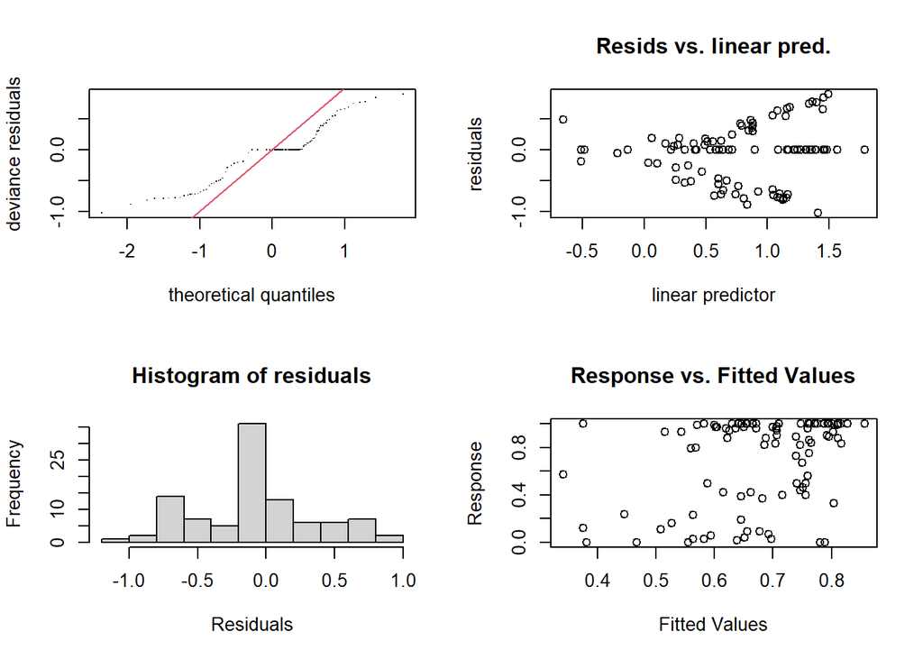

```
##
## Method: REML   Optimizer: outer newton
## full convergence after 11 iterations.
## Gradient range [-0.0007619733,1.953451e-05]
## (score -828.022 & scale 1).
## Hessian positive definite, eigenvalue range [2.678687e-05,68.58312].
## Model rank =  71 / 71
```

```
## Basis dimension (k) checking results. Low p-value (k-index<1) may
## indicate that k is too low, especially if edf is close to k'.
##
##                                            k'      edf k-index p-value
## s(causalness_lagged)                 1.90e+01 1.00e+00    1.00    0.52
## s(period)                            4.00e+00 1.03e+00    1.05    0.69
## s(causalness_lagged):languageItalian 1.90e+01 5.37e-03    1.00    0.50
## s(causalness_lagged):languageSpanish 1.90e+01 9.07e-01    1.00    0.50
## s(period):languageItalian            4.00e+00 8.32e-05    1.05    0.73
## s(period):languageSpanish            4.00e+00 9.55e-05    1.05    0.71
```

```r
gam.check(model1)
```

```r
#remove s(period, by = language, k = 5, bs = "cs", m= 1),


model2 <- gam(
  proportion_anticausative ~
    language + #you must include interaction terms as main effects too!
    s(causalness_lagged, k=20)+
    s(period, k=5)+
    s(causalness_lagged, by = language, k = 20, bs = "cs", m = 1),
  family = betar(link = "logit"),
  data = join
)

anova.gam(model1, model2, test = "Chisq")
```

```
## Analysis of Deviance Table
##
## Model 1: proportion_anticausative ~ language + s(causalness_lagged, k = 20) +
##     s(period, k = 5) + s(causalness_lagged, by = language, k = 20,
##     bs = "cs", m = 1) + s(period, by = language, k = 5, bs = "cs",
##     m = 1)
## Model 2: proportion_anticausative ~ language + s(causalness_lagged, k = 20) +
##     s(period, k = 5) + s(causalness_lagged, by = language, k = 20,
##     bs = "cs", m = 1)
##   Resid. Df Resid. Dev       Df Deviance Pr(>Chi)
## 1    93.449    -1666.3
## 2    93.435    -1666.3 0.014374 0.010322  0.03322 *
## ---
## Signif. codes:  0 '***' 0.001 '**' 0.01 '*' 0.05 '.' 0.1 ' ' 1
```

```r
compareML(model1, model2)
```

```
## model1: proportion_anticausative ~ language + s(causalness_lagged, k = 20) +
##     s(period, k = 5) + s(causalness_lagged, by = language, k = 20,
##     bs = "cs", m = 1) + s(period, by = language, k = 5, bs = "cs",
##     m = 1)
##
## model2: proportion_anticausative ~ language + s(causalness_lagged, k = 20) +
##     s(period, k = 5) + s(causalness_lagged, by = language, k = 20,
##     bs = "cs", m = 1)
##
## Model model2 preferred: lower REML score (0.000), and lower df (2.000).
## -----
##    Model    Score Edf Difference    Df
## 1 model1 -828.022  10
## 2 model2 -828.022   8     -0.000 2.000
##
## AIC difference: -0.01, model model1 has lower AIC.
```

```r
AIC(model1, model2)
```

```
##              df       AIC
## model1 6.244764 -1653.798
## model2 6.254698 -1653.788
```

```r
summary(model2)
```

```
##
## Family: Beta regression(0.253)
## Link function: logit
##
## Formula:
## proportion_anticausative ~ language + s(causalness_lagged, k = 20) +
##     s(period, k = 5) + s(causalness_lagged, by = language, k = 20,
##     bs = "cs", m = 1)
##
## Parametric coefficients:
##                 Estimate Std. Error z value Pr(>|z|)
## (Intercept)       0.6837     0.1772   3.859 0.000114 ***
## languageSpanish   0.1960     0.2685   0.730 0.465291
## ---
## Signif. codes:  0 '***' 0.001 '**' 0.01 '*' 0.05 '.' 0.1 ' ' 1
##
## Approximate significance of smooth terms:
##                                          edf Ref.df Chi.sq  p-value
## s(causalness_lagged)                 1.00017  1.000 13.053 0.000303 ***
## s(period)                            1.03086  1.061  1.773 0.203199
## s(causalness_lagged):languageItalian 0.01013 19.000  0.010 0.059782 .
## s(causalness_lagged):languageSpanish 0.90324 19.000  4.006 0.023209 *
## ---
## Signif. codes:  0 '***' 0.001 '**' 0.01 '*' 0.05 '.' 0.1 ' ' 1
##
## R-sq.(adj) =  0.102   Deviance explained = -1.4%
## -REML = -828.02  Scale est. = 1         n = 99
```

```r
model3 <- gam(
  proportion_anticausative ~
    language + #you must include interaction terms as main effects too!
    s(causalness_lagged, k=20)+
    #s(period, k=5)+
    s(causalness_lagged, by = language, k = 20, bs = "cs", m = 1),
  family = betar(link = "logit"),
  data = join
)

summary(model3)
```

```
##
## Family: Beta regression(0.25)
## Link function: logit
##
## Formula:
## proportion_anticausative ~ language + s(causalness_lagged, k = 20) +
##     s(causalness_lagged, by = language, k = 20, bs = "cs", m = 1)
##
## Parametric coefficients:
##                 Estimate Std. Error z value Pr(>|z|)
## (Intercept)       0.6826     0.1767   3.862 0.000112 ***
## languageSpanish   0.2038     0.2671   0.763 0.445554
## ---
## Signif. codes:  0 '***' 0.001 '**' 0.01 '*' 0.05 '.' 0.1 ' ' 1
##
## Approximate significance of smooth terms:
##                                          edf Ref.df Chi.sq p-value
## s(causalness_lagged)                 1.00055  1.001  0.856  0.3551
## s(causalness_lagged):languageItalian 0.91942 19.000  3.426  0.0258 *
## s(causalness_lagged):languageSpanish 0.03915 19.000  0.039  0.0452 *
## ---
## Signif. codes:  0 '***' 0.001 '**' 0.01 '*' 0.05 '.' 0.1 ' ' 1
##
## R-sq.(adj) =  0.117   Deviance explained = -1.24%
## -REML = -828.3  Scale est. = 1         n = 99
```

```r
anova.gam(model3, model2, test = "Chisq")
```

```
## Analysis of Deviance Table
##
## Model 1: proportion_anticausative ~ language + s(causalness_lagged, k = 20) +
##     s(causalness_lagged, by = language, k = 20, bs = "cs", m = 1)
## Model 2: proportion_anticausative ~ language + s(causalness_lagged, k = 20) +
##     s(period, k = 5) + s(causalness_lagged, by = language, k = 20,
##     bs = "cs", m = 1)
##   Resid. Df Resid. Dev      Df Deviance Pr(>Chi)
## 1    94.404    -1664.5
## 2    93.435    -1666.3 0.96863   1.7677   0.1768
```

```r
compareML(model3, model2)
```

```
## model3: proportion_anticausative ~ language + s(causalness_lagged, k = 20) +
##     s(causalness_lagged, by = language, k = 20, bs = "cs", m = 1)
##
## model2: proportion_anticausative ~ language + s(causalness_lagged, k = 20) +
##     s(period, k = 5) + s(causalness_lagged, by = language, k = 20,
##     bs = "cs", m = 1)
##
## Model model3 preferred: lower REML score (0.279), and lower df (2.000).
## -----
##    Model    Score Edf Difference     Df
## 1 model2 -828.022   8
## 2 model3 -828.301   6      0.279 -2.000
##
## AIC difference: -0.19, model model3 has lower AIC.
```

```r
AIC(model3, model2)
```

```
##              df       AIC
## model3 5.277750 -1653.975
## model2 6.254698 -1653.788
```

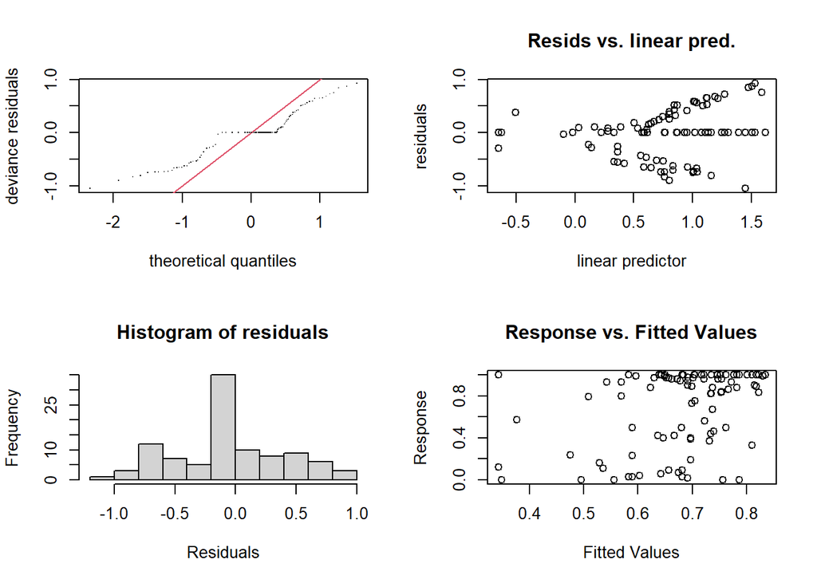

```
##
## Method: REML   Optimizer: outer newton
## full convergence after 15 iterations.
## Gradient range [-0.002804202,-3.399489e-05]
## (score -828.301 & scale 1).
## Hessian positive definite, eigenvalue range [3.400332e-05,68.54206].
## Model rank =  59 / 59
```

```
## Basis dimension (k) checking results. Low p-value (k-index<1) may
## indicate that k is too low, especially if edf is close to k'.
##
##                                           k'     edf k-index p-value
## s(causalness_lagged)                 19.0000  1.0005    0.99    0.40
## s(causalness_lagged):languageItalian 19.0000  0.9194    0.99    0.40
## s(causalness_lagged):languageSpanish 19.0000  0.0391    0.99    0.34
```

```r
gam.check(model3)
```

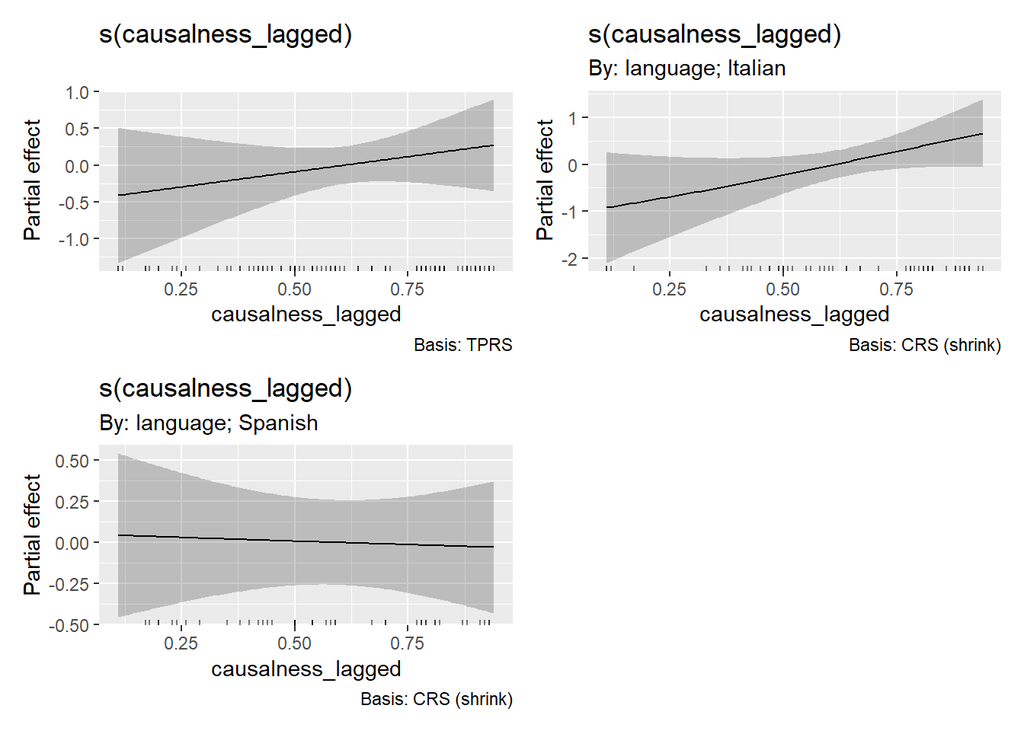

```r
 gratia::draw(model3)
```

```r
model4 <- gam(
  proportion_anticausative ~
    language + #you must include interaction terms as main effects too!
    #s(causalness_lagged, k=20)+
    #s(period, k=5)+
    s(causalness_lagged, by = language, k = 20, bs = "cs", m = 1),
  family = betar(link = "logit"),
  data = join
)

summary(model4)
```

```
##
## Family: Beta regression(0.25)
## Link function: logit
##
## Formula:
## proportion_anticausative ~ language + s(causalness_lagged, by = language,
##     k = 20, bs = "cs", m = 1)
##
## Parametric coefficients:
##                 Estimate Std. Error z value Pr(>|z|)
## (Intercept)       0.6802     0.1769   3.845 0.000121 ***
## languageSpanish   0.1825     0.2659   0.686 0.492543
## ---
## Signif. codes:  0 '***' 0.001 '**' 0.01 '*' 0.05 '.' 0.1 ' ' 1
##
## Approximate significance of smooth terms:
##                                            edf Ref.df Chi.sq  p-value
## s(causalness_lagged):languageItalian 1.1828015     19  14.62 8.56e-05 ***
## s(causalness_lagged):languageSpanish 0.0006152     19   0.00    0.607
## ---
## Signif. codes:  0 '***' 0.001 '**' 0.01 '*' 0.05 '.' 0.1 ' ' 1
##
## R-sq.(adj) =  0.107   Deviance explained = -1.23%
## -REML = -828.69  Scale est. = 1         n = 99
```

```r
anova.gam(model3, model4, test = "Chisq")
```

```
## Analysis of Deviance Table
##
## Model 1: proportion_anticausative ~ language + s(causalness_lagged, k = 20) +
##     s(causalness_lagged, by = language, k = 20, bs = "cs", m = 1)
## Model 2: proportion_anticausative ~ language + s(causalness_lagged, by = language,
##     k = 20, bs = "cs", m = 1)
##   Resid. Df Resid. Dev       Df  Deviance Pr(>Chi)
## 1    94.404    -1664.5
## 2    95.269    -1664.5 -0.86526 -0.026493   0.8269
```

```r
compareML(model3, model4)
```

```
## model3: proportion_anticausative ~ language + s(causalness_lagged, k = 20) +
##     s(causalness_lagged, by = language, k = 20, bs = "cs", m = 1)
##
## model4: proportion_anticausative ~ language + s(causalness_lagged, by = language,
##     k = 20, bs = "cs", m = 1)
##
## Model model4 preferred: lower REML score (0.393), and lower df (2.000).
## -----
##    Model     Score Edf Difference    Df
## 1 model3 -828.3010   6
## 2 model4 -828.6942   4     -0.393 2.000
##
## AIC difference: 1.61, model model4 has lower AIC.
```

```r
AIC(model3, model4)
```

```
##              df       AIC
## model3 5.277750 -1653.975
## model4 4.457267 -1655.589
```

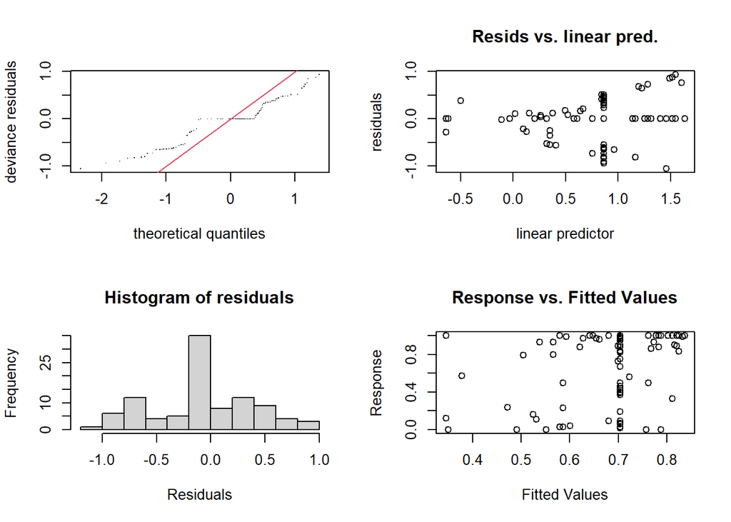

```
##
## Method: REML   Optimizer: outer newton
## full convergence after 11 iterations.
## Gradient range [-0.0002298107,-3.774758e-15]
## (score -828.6942 & scale 1).
## Hessian positive definite, eigenvalue range [0.0002297221,68.36275].
## Model rank =  40 / 40
```

```
## Basis dimension (k) checking results. Low p-value (k-index<1) may
## indicate that k is too low, especially if edf is close to k'.
##
##                                            k'      edf k-index p-value
## s(causalness_lagged):languageItalian 1.90e+01 1.18e+00    1.01    0.46
## s(causalness_lagged):languageSpanish 1.90e+01 6.15e-04    1.01    0.51
```

```r
gam.check(model4)
```

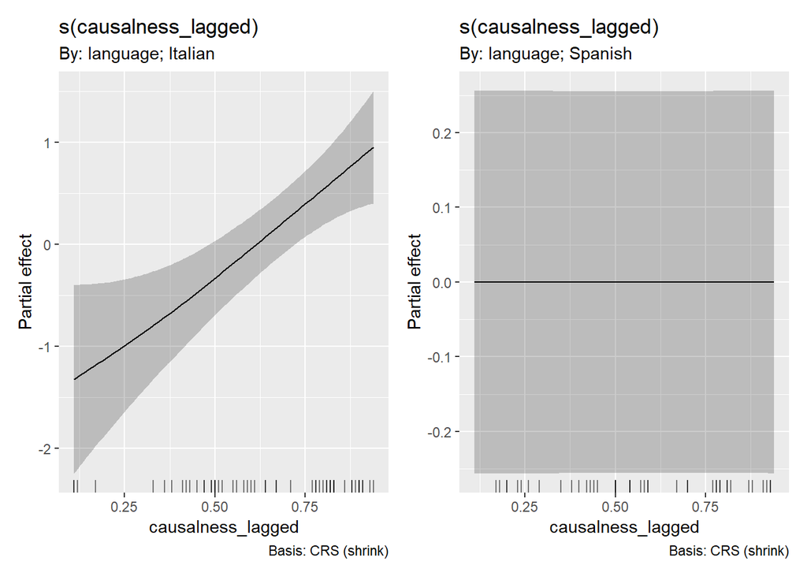

```r
gratia::draw(model4)
```

*Step 4: Print the results of the model

```r
results<-report::report_table(model4)
report::display(results)
```

| Parameter | Component | Coefficient | 95% CI | z | df | p | Std. Coef. | Std. Coef. 95% CI | Fit |
| --- | --- | --- | --- | --- | --- | --- | --- | --- | --- |
| (Intercept) | conditional | 0.68 | (0.33, 1.03) | 3.84 |  | < .001 | 0.68 | (0.33, 1.03) |  |
| languageSpanish | conditional | 0.18 | (-0.34, 0.70) | 0.69 |  | 0.493 | 0.18 | (-0.34, 0.70) |  |
| Smooth term (causalness lagged) × languageItalian | smooth_terms |  |  | 14.62 | 1.18 | < .001 |  |  |  |
| Smooth term (causalness lagged) × languageSpanish | smooth_terms |  |  | 1.73e-04 | 6.15e-04 | 0.607 |  |  |  |
| AIC |  |  |  |  |  |  |  |  | -1655.59 |
| AICc |  |  |  |  |  |  |  |  | -1655.07 |
| BIC |  |  |  |  |  |  |  |  | -1644.02 |
| R2 |  |  |  |  |  |  |  |  | 0.11 |
| Sigma |  |  |  |  |  |  |  |  | 1.00 |

## Visualise the results

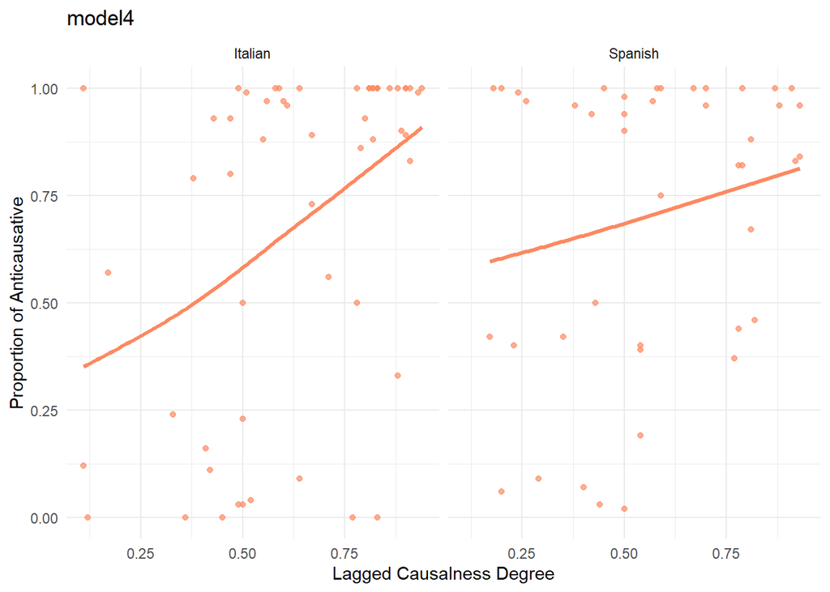

```r
library(mgcv)
model<-model4

# Incorporate predictions from beta regression to the original dataset
fit <- join %>%
  mutate(fit = predict(model4, newdata = join, type = "response"))

ggplot(fit, aes(x = causalness_lagged, y = proportion_anticausative, color = causalness_lagged)) +
  geom_point( alpha = 0.7, color= "#fc8961") +
  geom_smooth(method = "gam", se = F, aes(group = language), color= "#fc8961", linewidth = 1.2) +
    facet_wrap(~ language) +
  labs(
    title = "model4",
    x = "Lagged Causalness Degree",
    y = "Proportion of Anticausative",
    color = "Lagged Causalness Degree"
  ) +
  ylim(0,1)+
  theme_minimal() +
  theme(legend.position = "bottom")
```

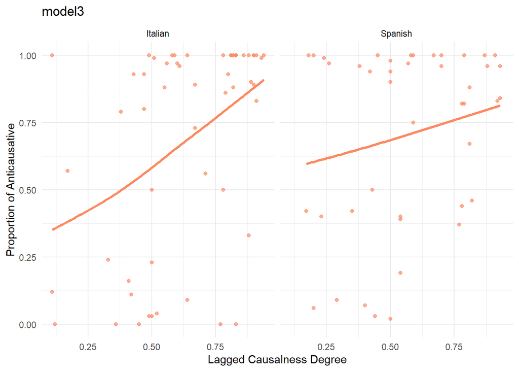

```r
fit2 <- join %>%
  mutate(fit = predict(model3, newdata = join, type = "response"))

ggplot(fit2, aes(x = causalness_lagged, y = proportion_anticausative, color = causalness_lagged)) +
  geom_point( alpha = 0.7, color= "#fc8961") +
  geom_smooth(method = "gam", se = F, aes(group = language), color= "#fc8961", linewidth = 1.2) +
    facet_wrap(~ language) +
  labs(
    title = "model3",
    x = "Lagged Causalness Degree",
    y = "Proportion of Anticausative",
    color = "Lagged Causalness Degree"
  ) +
  ylim(0,1)+
  theme_minimal() +
  theme(legend.position = "bottom")
```